# 수리통계학 Ⅱ - chap 7 실습

## 2-(4). 20개 + 10개, 10개의 미래 관측치의 평균에 대한 예측 분포.

```r
# 필요한 라이브러리 불러오기
library(ggplot2)

# 사후분포
mu0 = 150; sig0 = sqrt(21); n = 20; xbar = 150; sig = sqrt(21)
c= n/sig^2 ; c0=1/sig0^2; w = c/(c+c0)
mu.post = w * xbar + (1-w)* mu0; sig.post = sqrt( 1/(c+c0) )

# 예측분포
n_new = 10
s_new = sig / sqrt(n_new) # 새로운 관측치들의 평균에 대한 표준편차
mu.new = mu.post; sig.new = sqrt( sig.post^2 + s_new^2 )
mu.new;sig.new
```

```
## [1] 150
```

```
## [1] 1.760682
```

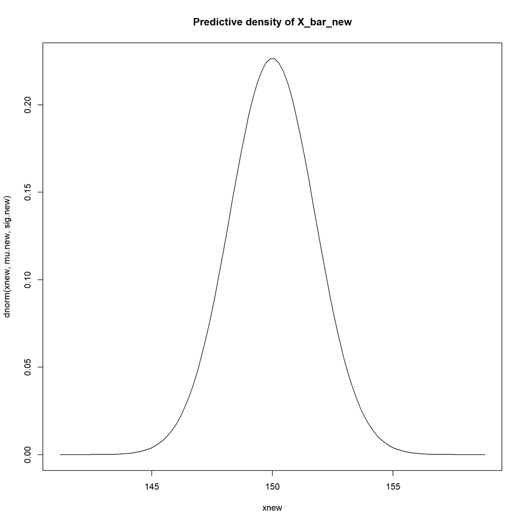

```r
# 예측 분포 그리기
xnew=seq(mu.new - 5* sig.new , mu.new + 5* sig.new, length=100)
plot(xnew, dnorm(xnew, mu.new, sig.new),type="l", main="Predictive density of X_bar_new")
```

## 2-(5). 위의 10개의 미래 관측치의 평균이 (150, 153)의 구간에 속할 확률은?

```r
prob = pnorm(153, mu.new, sig.new) - pnorm(150, mu.new, sig.new)
prob #0.4557988
```

```
## [1] 0.4557988
```

# 3. 증명

$$\pi(\theta) = 1, \quad \pi(\sigma^2) = \frac{1}{\sigma^2}, \quad
\pi(\theta, \sigma^2) = \pi(\theta) \cdot \pi(\sigma^2)$$

$$L(\theta, \sigma^2|x_1, ..., x_n) = (2\pi\sigma^2)^{-n/2} \cdot
\exp\left(-\frac{\sum_{i=1}^{n}(x_i - \theta)^2}{2\sigma^2}\right)$$

$$\pi(\theta, \sigma^2|x_1, ..., x_n) \propto (2\pi\sigma^2)^{-n/2} \cdot
\exp\left(-\frac{\sum_{i=1}^{n}(x_i - \theta)^2}{2\sigma^2}\right) \cdot
\pi(\theta) \cdot \pi(\sigma^2)$$

$$\theta의 사후분포\\
\pi(\theta|x_1, ..., x_n, \sigma^2) \sim N(\bar{x},\sigma^2/n)$$

$$\sigma^2의 사후분포\\
\pi(\sigma^2|x_1, ..., x_n) \sim IG\left(\frac{n-1}{2},
\frac{S}{2}\right)$$

# 4. 이화여대 통계학과생들의 A 과목 기말고사 성적 X가 미지의 평균 $\theta$와 분산 $\sigma^2$을 갖는 정규분포, 20명의 학생

## 4-(1).$\sigma^2$이 주어졌을 때 $\theta$의 조건부 사후분포

$$\pi(\theta|x_1,...,x_{20},\sigma^2) \sim N(\bar{x},\sigma^2/n)$$

```r
x <-  c(95, 77, 63, 34, 87, 89, 92, 85, 98, 52, 48, 72, 89, 63, 67, 78, 92, 85, 78, 99)
x_bar <- mean(x)
```

$$\pi(\theta|x_1,...,x_{20},\sigma^2) \sim N(77.15,\sigma^2/20)$$

## 4-(2).$\theta$의 사후분포, 베이즈 추정치

$$\pi(\theta|x_1,...,x_{20}) \sim t_{n-1}(\bar{x},s^2/n)$$

```r
# 데이터 입력
scores <- c(95, 77, 63, 34, 87, 89, 92, 85, 98, 52, 48, 72, 89, 63, 67, 78, 92, 85, 78, 99)

# 표본 개수
n <- length(scores)

# 표본 평균 (세타의 베이지 추정치)
bayes_estimate_theta <- mean(scores)

# 표본 분산
s2 <- sd(scores)

# 세타의 사후분포의 분산
post_var_theta <- (s2)^2 / n
bayes_estimate_theta;post_var_theta  #[1] 77.15 [1] 15.91724
```

```
## [1] 77.15
```

```
## [1] 15.91724
```

$$\pi(\theta|x_1,...,x_{20}) \sim N(77.15, 15.91724)$$

## 4-(3).$\theta$의 고전적 추정치와 베이즈 추정치 비교

$\theta$의 고전적 추정치는 표본평균, 불편추정량
$$E[\bar{x}] = \theta \\$$

$\theta$의 고전적 추정치와 베이지 추정치는 동일

```r
bayes_estimate_theta #77.15
```

```
## [1] 77.15
```

## 4-(4).$\sigma^2$의 사후분포, 고전적 추정치와 베이즈 추정치 비교

$$\pi(\sigma^2|x_1,...,x_{20}) \sim IG(\frac{n-1}{2},\frac{S}{2}) \\
S = s^2*(n-1)$$

```r
library(MCMCpack)
```

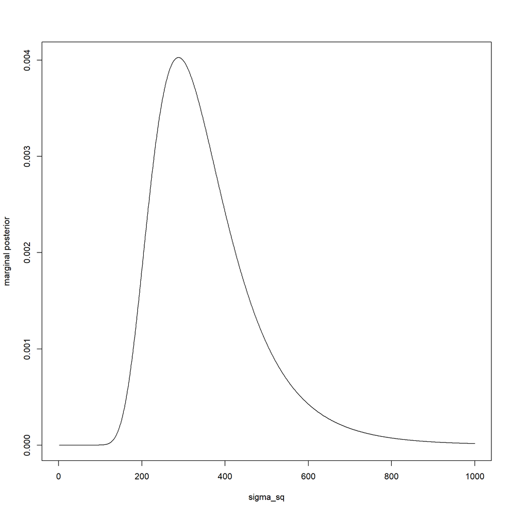

```r
n <- length(scores)
x_bar <- mean(scores)
s <- sd(scores)
a <- (n-1)/2
S <- (s^2)*(n-1)
b <- S / 2
sigsq.grid=seq(0,1000,length=1000)


post.sigsq = dinvgamma(sigsq.grid,a, scale=b)
plot(sigsq.grid,post.sigsq,type="l",xlab="sigma_sq",ylab="marginal posterior")
```

```r
a;b
```

```
## [1] 9.5
```

```
## [1] 3024.275
```

```r
#베이즈 추정치
b/(a-1)
```

```
## [1] 355.7971
```

```r
#고전적 추정치
var(scores)
```

```
## [1] 318.3447
```

$$\pi(\sigma^2|x_1,...,x_{20}) \sim IG(9.5,3024.275)\\
고전적 \sigma^2 = 318.3447\\
베이즈 \sigma^2 = 355.7971$$

# 5. X1,…Xn이 독립적으로 $\theta$와 분산 $1$을 갖는 정규분포, n = 20, $\bar{x}=0.33$

## 5-(1).$\theta$의 사후분포 유도, 사후밀도함수 그림

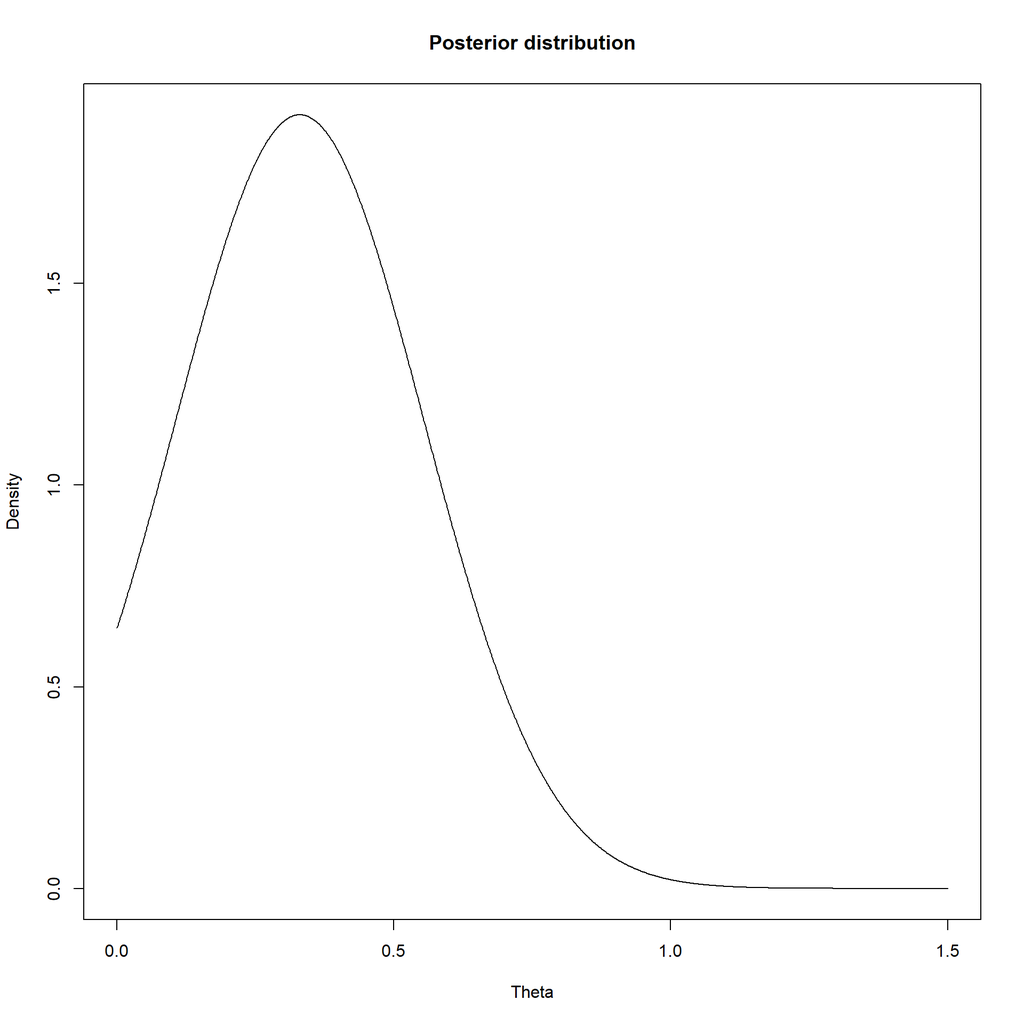

```r
library(msm)
n = 20
x_bar = 0.33

# 사후분포를 그래프로 나타냅니다.
theta = seq(0, 1.5, length.out = 1000)
posterior = dtnorm(theta, mean = x_bar, sd = sqrt(1/n), lower = 0)
plot(theta, posterior, type = "l", xlab = "Theta", ylab = "Density", main = "Posterior distribution")
```

```r
sqrt(1/n)^2
```

```
## [1] 0.05
```

## 5-(2).$\theta$의 95% 최대사후구간을 구하라.

```r
HPDgrid <- function(prob,level=0.95){
  prob.sort=sort(prob,decreasing = T)
  M=min(which(cumsum(prob.sort)>=level))
  height=prob.sort[M]
  HPD.index=which(prob>=height)
  HPD.level=sum(prob[HPD.index])
  res=list(index=HPD.index, level=HPD.level)
  return(res)
}

prob=posterior/sum(posterior)
HPD <- HPDgrid(prob,0.95)
HPD.grid <- c(min(theta[HPD$index]),max(theta[HPD$index]))
HPD.grid
```

```
## [1] 0.0000000 0.7057057
```

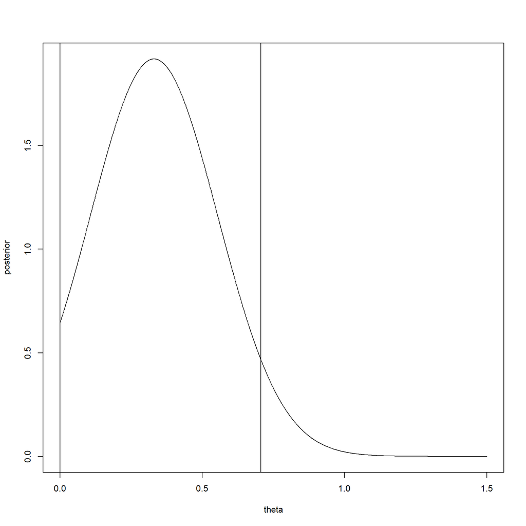

```r
plot(theta,posterior,type = 'l')
abline(v=HPD.grid)
```

$$\theta의 HPD = (0.0000000 0.7057057)$$

# References {-}s

[R tutorial](https://cran.r-project.org/doc/manuals/r-release/R-intro.html)

ⓒ Statistical Methods, Gachon University